# Midterm - completed with help from Teresa

Ting-fen Lin

5/1/2019

Part A: Data

```r
download_file <- function(year) {
    link <- glue::glue("https://www.oregon.gov/ode/educator-resources/assessment/TestResults20{year}/pagr_schools_ela_raceethnicity_{year-1}{year}.xlsx")
    rio::import(link, setclass = "tibble", na = c("-", "--", "*"))
}

original <- map_df(c(15:18), download_file)

df_original <- janitor::clean_names(original) %>%
  filter(student_group == "White" | student_group == "Hispanic/Latino") %>%
  dplyr::select(academic_year, district, school, student_group, grade_level,
         number_level_4, number_level_3, number_level_2, number_level_1) %>%
  gather(level, n, number_level_4:number_level_1) %>%
  filter(!is.na(n)) %>%
  mutate(level = parse_number(level)) %>%
  arrange(academic_year, district, student_group, grade_level, level)

df_original
```

```
## # A tibble: 90,576 x 7
##    academic_year district  school     student_group grade_level level     n
##    <chr>         <chr>     <chr>      <chr>         <chr>       <dbl> <dbl>
##  1 2014-2015     Adrian S… Adrian El… Hispanic/Lat… Grade 3         1     2
##  2 2014-2015     Adrian S… Adrian El… Hispanic/Lat… Grade 3         2     1
##  3 2014-2015     Adrian S… Adrian El… Hispanic/Lat… Grade 3         3     2
##  4 2014-2015     Adrian S… Adrian El… Hispanic/Lat… Grade 3         4     1
##  5 2014-2015     Adrian S… Adrian El… Hispanic/Lat… Grade 6         1     2
##  6 2014-2015     Adrian S… Adrian El… Hispanic/Lat… Grade 6         2     3
##  7 2014-2015     Adrian S… Adrian El… Hispanic/Lat… Grade 6         3     2
##  8 2014-2015     Adrian S… Adrian El… Hispanic/Lat… Grade 6         4     0
##  9 2014-2015     Adrian S… Adrian El… Hispanic/Lat… Grade 7         1     2
## 10 2014-2015     Adrian S… Adrian El… Hispanic/Lat… Grade 7         2     2
## # … with 90,566 more rows
```

Calculate the cumulative n for each school by student group, grade, and academic year. The result should look like the below. Hint, look at ?base::cumsum

```r
df_cumulative <- df_original %>% group_by(academic_year, school, student_group, grade_level) %>%
  mutate(cn = cumsum(n))

df_cumulative
```

```
## # A tibble: 90,576 x 8
## # Groups:   academic_year, school, student_group, grade_level [21,921]
##    academic_year district school student_group grade_level level     n
##    <chr>         <chr>    <chr>  <chr>         <chr>       <dbl> <dbl>
##  1 2014-2015     Adrian … Adria… Hispanic/Lat… Grade 3         1     2
##  2 2014-2015     Adrian … Adria… Hispanic/Lat… Grade 3         2     1
##  3 2014-2015     Adrian … Adria… Hispanic/Lat… Grade 3         3     2
##  4 2014-2015     Adrian … Adria… Hispanic/Lat… Grade 3         4     1
##  5 2014-2015     Adrian … Adria… Hispanic/Lat… Grade 6         1     2
##  6 2014-2015     Adrian … Adria… Hispanic/Lat… Grade 6         2     3
##  7 2014-2015     Adrian … Adria… Hispanic/Lat… Grade 6         3     2
##  8 2014-2015     Adrian … Adria… Hispanic/Lat… Grade 6         4     0
##  9 2014-2015     Adrian … Adria… Hispanic/Lat… Grade 7         1     2
## 10 2014-2015     Adrian … Adria… Hispanic/Lat… Grade 7         2     2
## # … with 90,566 more rows, and 1 more variable: cn <dbl>
```

Reformat the data so it looks like the below, removing n and filling by cn. Remove rows that have missing data for either student group.

```r
df_student_group <- df_cumulative %>%
  select(-n) %>%
  spread(student_group, cn) %>%
  janitor::clean_names() %>%
  filter(!is.na(hispanic_latino), !is.na(white))

df_student_group
```

```
## # A tibble: 33,948 x 7
## # Groups:   academic_year, school, grade_level [8,217]
##    academic_year district  school   grade_level level hispanic_latino white
##    <chr>         <chr>     <chr>    <chr>       <dbl>           <dbl> <dbl>
##  1 2014-2015     Adrian S… Adrian … Grade 3         1               2     0
##  2 2014-2015     Adrian S… Adrian … Grade 3         2               3     4
##  3 2014-2015     Adrian S… Adrian … Grade 3         3               5     7
##  4 2014-2015     Adrian S… Adrian … Grade 3         4               6    11
##  5 2014-2015     Adrian S… Adrian … Grade 6         1               2     0
##  6 2014-2015     Adrian S… Adrian … Grade 6         2               5     3
##  7 2014-2015     Adrian S… Adrian … Grade 6         3               7     8
##  8 2014-2015     Adrian S… Adrian … Grade 6         4               7     9
##  9 2014-2015     Adrian S… Adrian … Grade 7         1               2     3
## 10 2014-2015     Adrian S… Adrian … Grade 7         2               4     5
## # … with 33,938 more rows
```

Part B: Achievement gaps Estimate an achievement gap effect size for every school in the state that reported data on both student groups (i.e., using the data we created above), for each grade level in each academic year.

```r
gap <- function(data, ref, foc) {
    x <- data[[ref]]
    y <- data[[foc]]
    auc <- pracma::trapz(y / y[length(x)],
                         x / x[length(x)])
    sqrt(2)*qnorm(auc)
}

df_estimate <- df_student_group %>%
  group_by(academic_year, grade_level, school) %>%
  nest() %>%
  mutate(es = map_dbl(data, ~ gap(.x, "white", "hispanic_latino")))

df_estimate
```

```
## # A tibble: 8,217 x 5
##    academic_year grade_level   school                data                es
##    <chr>         <chr>         <chr>                 <list>           <dbl>
##  1 2014-2015     Grade 3       Adrian Elementary Sc… <tibble [4 × … -0.609
##  2 2014-2015     Grade 6       Adrian Elementary Sc… <tibble [4 × … -0.972
##  3 2014-2015     Grade 7       Adrian Elementary Sc… <tibble [4 × … -0.609
##  4 2014-2015     Grade 3       Amity Elementary Sch… <tibble [4 × … -0.419
##  5 2014-2015     Grade 4       Amity Elementary Sch… <tibble [4 × … -0.849
##  6 2014-2015     Grade 5       Amity Elementary Sch… <tibble [4 × … -0.822
##  7 2014-2015     Grade 6       Amity Middle School   <tibble [4 × … -0.106
##  8 2014-2015     Grade 7       Amity Middle School   <tibble [4 × … -0.556
##  9 2014-2015     Grade 8       Amity Middle School   <tibble [4 × … -0.0322
## 10 2014-2015     Grade HS (11) Ashland High School   <tibble [4 × … -0.804
## # … with 8,207 more rows
```

```r
df_estimate_district <- df_student_group %>%
  group_by(academic_year, grade_level, school, district) %>%
  nest() %>%
  mutate(es = map_dbl(data, ~ gap(.x, "white", "hispanic_latino")))

df_estimate_district
```

```
## # A tibble: 8,487 x 6
##    academic_year grade_level  school          district   data            es
##    <chr>         <chr>        <chr>           <chr>      <list>       <dbl>
##  1 2014-2015     Grade 3      Adrian Element… Adrian SD… <tibble [… -0.609
##  2 2014-2015     Grade 6      Adrian Element… Adrian SD… <tibble [… -0.972
##  3 2014-2015     Grade 7      Adrian Element… Adrian SD… <tibble [… -0.609
##  4 2014-2015     Grade 3      Amity Elementa… Amity SD … <tibble [… -0.419
##  5 2014-2015     Grade 4      Amity Elementa… Amity SD … <tibble [… -0.849
##  6 2014-2015     Grade 5      Amity Elementa… Amity SD … <tibble [… -0.822
##  7 2014-2015     Grade 6      Amity Middle S… Amity SD … <tibble [… -0.106
##  8 2014-2015     Grade 7      Amity Middle S… Amity SD … <tibble [… -0.556
##  9 2014-2015     Grade 8      Amity Middle S… Amity SD … <tibble [… -0.0322
## 10 2014-2015     Grade HS (1… Ashland High S… Ashland S… <tibble [… -0.804
## # … with 8,477 more rows
```

The plot below shows the achievement gap estimates for one school by grade in Ashland School District during the 2017-18 school year. Produce a similar plot to the below (noting the school, academic year, and school district) for each of the first 100 unique school/year/district combinations. Hint - you’ll want to use your effect size data from from the previous question, nest it, then apply slice(1:100). Note that the only reason I’m asking you to slice the data frame is just to reduce run time. In reality, you would do this for all school/year/district combinations.

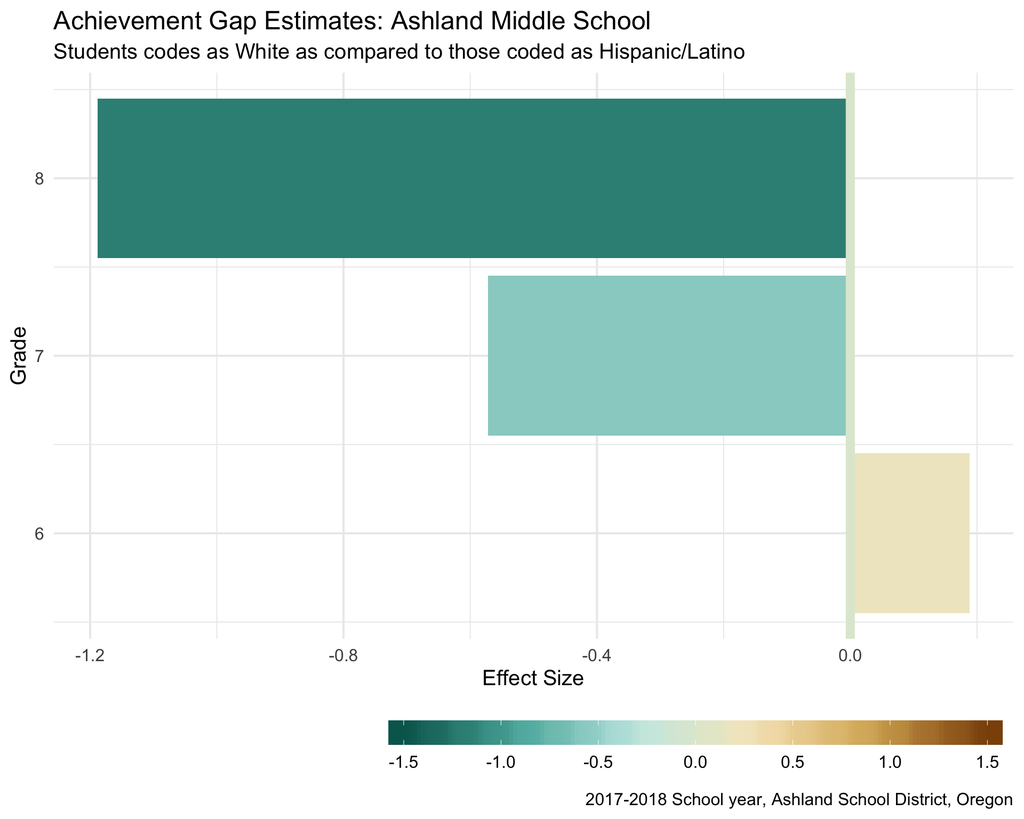

```r
temp <- df_estimate_district %>%
  select(-data) %>%
  # group_by(academic_year, school, district) %>%
  # # nest() %>%
  # # mutate(title = glue::glue("Achievement Gap Estimates:{school}"),
  # #        caption = glue::glue("{academic_year} School year, {district}, Oregon")) %>%
  # # unnest() %>%
  filter(academic_year == "2017-2018",
         school == "Ashland Middle School")

temp %>%
  mutate(grade_level = parse_number(grade_level)) %>%
  ggplot(aes(x = grade_level, y = es, fill = es)) +
  geom_col() +
  scale_fill_distiller(type = "seq",
                       limits = c(-1.5, 1.5),
                       palette = "BrBG",
                       direction = -1)+
  geom_hline(yintercept = 0, size = 3, color = "#e0e9d5") +
  coord_flip() +
  theme_minimal(base_size = 15) +
  theme(legend.position = "bottom",
        legend.justification = "right",
        legend.key.width = unit(6, "line")) +
  labs(x = "Grade",
       y = "Effect Size",
       fill = "",
       title = "Achievement Gap Estimates: Ashland Middle School",
       subtitle = "Students codes as White as compared to those coded as Hispanic/Latino",
       caption = "2017-2018 School year, Ashland School District, Oregon")
```

```r
## not sure why "glue::glue("Achievement Gap Estimates: {school}")" and
## "glue::glue("{academic_year} School year, {district}, Oregon")" don't work here
```

#### Slice the dataset and produce multiple plots

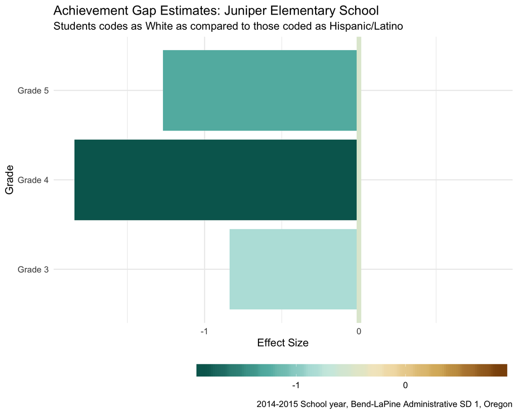

```r
df_plot <- df_estimate_district %>%
  select(-data) %>%
  group_by(academic_year, school, district) %>%
  nest() %>%
  slice(1:100) %>%
  # mutate(title = glue::glue("Achievement Gap Estimates:{school}"),
  #        caption = glue::glue("{academic_year} School year, {district}, Oregon")) %>%
  unnest()


final_plots <- df_plot %>%
  group_by(academic_year, school, district) %>%
  nest() %>%
  mutate(plots = pmap(list(academic_year, school, district, data),
                      ~ggplot(..4, aes(x = grade_level, y = es, fill = es)) +
                        geom_col(aes(fill = es)) +
                        scale_fill_distiller(type = "seq",
                                             limits = c(min(df_plot$es), max(df_plot$es)),
                                             palette = "BrBG",
                                             direction = -1) +
                        ylim(min(df_plot$es), max(df_plot$es)) +
                        geom_hline(yintercept = 0, size = 3, color = "#e0e9d5") +
                        coord_flip() +
                        theme_minimal(base_size = 15) +
                        theme(legend.position = "bottom",
                              legend.justification = "right",
                              legend.key.width = unit(6, "line")) +
                        labs(x = "Grade",
                             y = "Effect Size",
                             fill = "",
                             subtitle = "Students codes as White as compared to those coded as Hispanic/Latino",
                             title = glue::glue("Achievement Gap Estimates: {..2}"),
                             caption = glue::glue("{..1} School year, {..3}, Oregon"))))

final_plots$plots[[78]]
```

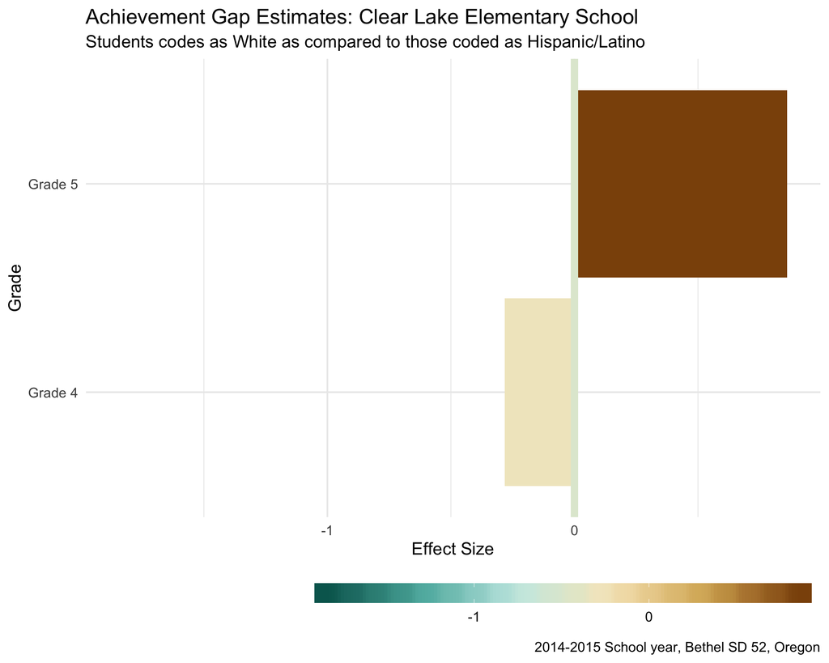

```r
final_plots$plots[[91]]
```

Save the plots into a “plots” directory. Make sure the file names are meaningful.

```r
fs::dir_create(here::here("plots"))

files_year <- final_plots$academic_year
files_school <- str_replace_all(tolower(final_plots$school), " ", "-")
files_district <- str_replace_all(tolower(final_plots$district), " ", "-")
files <- glue::glue("{files_year}-{files_district}-{files_school}")

paths <- here::here("plots", glue::glue("{files}.png"))

walk2(paths, final_plots$plots, ggsave,
      width = 9.5,
      height = 6.5,
      dpi = 500)
```